# Data Wrangling Report(WeRateDogs)

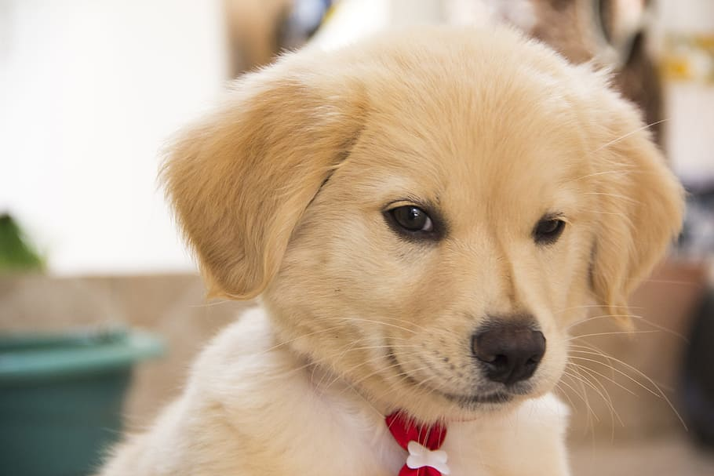

## Project Objectives

The tasks completed in this project are as follows:

Step 1: Gathering data

Step 2: Assessing data

Step 3: Cleaning data

Step 4: Storing data

Step 5: Analyzing, and visualizing data

Step 6: Reporting

- Data wrangling efforts
- Data analyses and visualizations

### Additional Project Requirement

In this analysis, only original tweets/ratings that have images should be used (no retweets nor replies should be used).

## Step 1: Data Gathering

**Steps**

- I directly downloaded the WeRateDogs Twitter archive data **(twitter_archive_enhanced.csv)**. Then, the file was read into a dataframe called **twitter**.
- The Requests library was used to programmatically download the **image_predictions.tsv** file and the file was read into a dataframe called **image**.
- As I did not get any feedback from Twitter after applying for the Twitter developer account, I directly downloaded the **tweet_json.tx** through the shortcut approach provided. After downloading, I read this .txt file line by line into a pandas DataFrame called **tweet** with (at minimum) tweet ID, retweet count, and favorite count.

## Step 2: Assessing Data

After the first step, the three datasets were assessed visually and programmatically for quality and tidiness issues.In addition, I also used Excel to perform a quick visual assessment of the **twitter** dataset. The following quality issues were observed:

### Quality issues

- **twitter**
1. According to one of the project's requirements, we only want original ratings (no retweets) that have images. The retweeted tweets can be seen in columns like 'retweeted_status_id', 'retweeted_status_user_id', and 'retweeted_status_timestamp'.
2. Timestamp is an object instead of a datetime
3. In the name column, many entries contain invalid dog names such as none, a, quite, such, etc.
4. There are several duplicates in the expanded_url column.
5. For the dog styles (puppo, doggo, floofer, and pupper columns), missing values are represented as 'None' instead of 'NaN'.
6. There are inconsistencies in the name column with some dog names starting with capital letters while some starts with small letters.
7. Extract content from source column.
8. Cleaning rating_numerator and rating_denominator.
- **image**
1. There are duplicated entries with the same **jpg_url** but different tweet_id column.
2. There are inconsistencies in the columns like **p1, p2, p3** with some dog names starting with capital letters while some starts with small letters.
- **tweet**
1. create_date is an object instead of a datetime.
- General
1. tweet_id column in all the tables is stored as an int instead of a string.

### Tidiness issues

- **twitter**
1. Dog stages (doggo, floofer, pupper, and puppo) are in different columns and some dogs have more than one style:
   - tweet_id = 854010172552949000 (doggo and floofer)
   - tweet_id = 855851453814013000 (doggo and puppo) etc.
2. Merge the three datasets into one file.

## Step 3: Cleaning Data

After step 2, the three datasets were cleaned based on all the quality and tidiness issuess discovered during the data assessment stage. In addition, Excel was used to perform a quick visual assessment of the twitter data.

## Step 4: Storing Data

The cleaned three datasets were then merged together using the tweet_id and then the cleaned master DataFrame was stored in a CSV file named **twitter_archive_master.csv**.

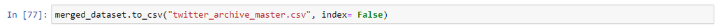

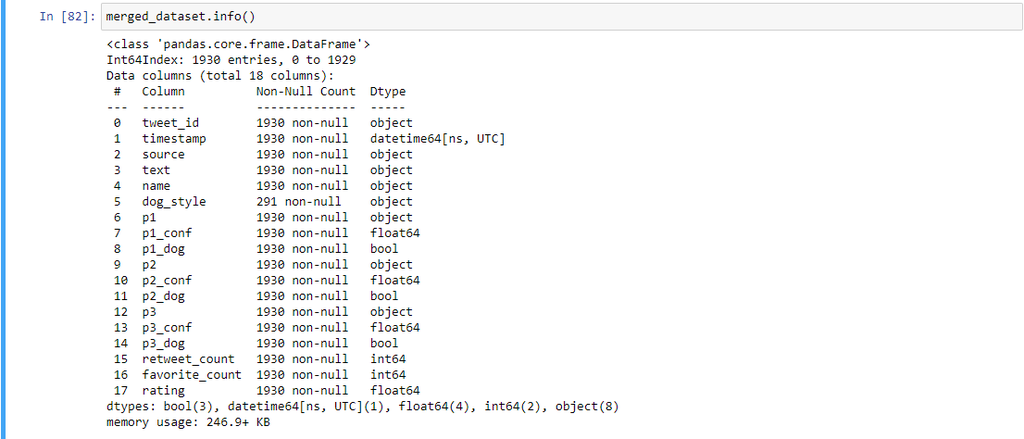